# students_data_analysis

## Analyzing student data to uncover performance insights and identify factors influencing academic achievemen

```python
import numpy as np
import pandas as pd
import matplotlib.pyplot as plt
import seaborn as sns
```

```python
df= pd.read_csv('students_detail.csv')
print(df.head())
```

```
   Unnamed: 0  Gender EthnicGroup          ParentEduc     LunchType TestPrep  \
0           0  female         NaN   bachelor's degree      standard     none
1           1  female     group C        some college      standard      NaN
2           2  female     group B     master's degree      standard     none
3           3    male     group A  associate's degree  free/reduced     none
4           4    male     group C        some college      standard     none

  ParentMaritalStatus PracticeSport IsFirstChild  NrSiblings TransportMeans  \
0             married     regularly          yes         3.0     school_bus
1             married     sometimes          yes         0.0            NaN
2              single     sometimes          yes         4.0     school_bus
3             married         never           no         1.0            NaN
4             married     sometimes          yes         0.0     school_bus

  WklyStudyHours  MathScore  ReadingScore  WritingScore
0            < 5         71            71            74
1         5 - 10         69            90            88
2            < 5         87            93            91
3         5 - 10         45            56            42
4         5 - 10         76            78            75
```

```python
df.describe()
```

|  | Unnamed: 0 | NrSiblings | MathScore | ReadingScore | WritingScore |
| --- | --- | --- | --- | --- | --- |
| count | 30641.000000 | 29069.000000 | 30641.000000 | 30641.000000 | 30641.000000 |
| mean | 499.556607 | 2.145894 | 66.558402 | 69.377533 | 68.418622 |
| std | 288.747894 | 1.458242 | 15.361616 | 14.758952 | 15.443525 |
| min | 0.000000 | 0.000000 | 0.000000 | 10.000000 | 4.000000 |
| 25% | 249.000000 | 1.000000 | 56.000000 | 59.000000 | 58.000000 |
| 50% | 500.000000 | 2.000000 | 67.000000 | 70.000000 | 69.000000 |
| 75% | 750.000000 | 3.000000 | 78.000000 | 80.000000 | 79.000000 |
| max | 999.000000 | 7.000000 | 100.000000 | 100.000000 | 100.000000 |

```python
df.info()
```

```
<class 'pandas.core.frame.DataFrame'>
RangeIndex: 30641 entries, 0 to 30640
Data columns (total 15 columns):
 #   Column               Non-Null Count  Dtype
---  ------               --------------  -----
 0   Unnamed: 0           30641 non-null  int64
 1   Gender               30641 non-null  object
 2   EthnicGroup          28801 non-null  object
 3   ParentEduc           28796 non-null  object
 4   LunchType            30641 non-null  object
 5   TestPrep             28811 non-null  object
 6   ParentMaritalStatus  29451 non-null  object
 7   PracticeSport        30010 non-null  object
 8   IsFirstChild         29737 non-null  object
 9   NrSiblings           29069 non-null  float64
 10  TransportMeans       27507 non-null  object
 11  WklyStudyHours       29686 non-null  object
 12  MathScore            30641 non-null  int64
 13  ReadingScore         30641 non-null  int64
 14  WritingScore         30641 non-null  int64
dtypes: float64(1), int64(4), object(10)
memory usage: 3.5+ MB
```

```python
df.isnull().sum()
```

```
Unnamed: 0                0
Gender                    0
EthnicGroup            1840
ParentEduc             1845
LunchType                 0
TestPrep               1830
ParentMaritalStatus    1190
PracticeSport           631
IsFirstChild            904
NrSiblings             1572
TransportMeans         3134
WklyStudyHours          955
MathScore                 0
ReadingScore              0
WritingScore              0
dtype: int64
```

```python
df=df.drop('Unnamed: 0',axis=1)
df
```

|  | Gender | EthnicGroup | ParentEduc | LunchType | TestPrep | ParentMaritalStatus | PracticeSport | IsFirstChild | NrSiblings | TransportMeans | WklyStudyHours | MathScore | ReadingScore | WritingScore |
| --- | --- | --- | --- | --- | --- | --- | --- | --- | --- | --- | --- | --- | --- | --- |
| 0 | female | NaN | bachelor's degree | standard | none | married | regularly | yes | 3.0 | school_bus | < 5 | 71 | 71 | 74 |
| 1 | female | group C | some college | standard | NaN | married | sometimes | yes | 0.0 | NaN | 5 - 10 | 69 | 90 | 88 |
| 2 | female | group B | master's degree | standard | none | single | sometimes | yes | 4.0 | school_bus | < 5 | 87 | 93 | 91 |
| 3 | male | group A | associate's degree | free/reduced | none | married | never | no | 1.0 | NaN | 5 - 10 | 45 | 56 | 42 |
| 4 | male | group C | some college | standard | none | married | sometimes | yes | 0.0 | school_bus | 5 - 10 | 76 | 78 | 75 |
| ... | ... | ... | ... | ... | ... | ... | ... | ... | ... | ... | ... | ... | ... | ... |
| 30636 | female | group D | high school | standard | none | single | sometimes | no | 2.0 | school_bus | 5 - 10 | 59 | 61 | 65 |
| 30637 | male | group E | high school | standard | none | single | regularly | no | 1.0 | private | 5 - 10 | 58 | 53 | 51 |
| 30638 | female | NaN | high school | free/reduced | completed | married | sometimes | no | 1.0 | private | 5 - 10 | 61 | 70 | 67 |
| 30639 | female | group D | associate's degree | standard | completed | married | regularly | no | 3.0 | school_bus | 5 - 10 | 82 | 90 | 93 |
| 30640 | male | group B | some college | standard | none | married | never | no | 1.0 | school_bus | 5 - 10 | 64 | 60 | 58 |

30641 rows × 14 columns

# Gender Ditribution

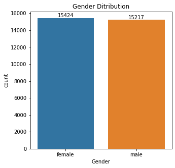

```python
plt.figure(figsize=(5,5))
ax=sns.countplot(data=df,x='Gender')
plt.title('Gender Ditribution')
ax.bar_label(ax.containers[0])
plt.show()
```

### Based on the chart above, our analysis reveals that there are a greater number of females in the dataset compared to males.

```python
gb= df.groupby('ParentEduc').agg({'MathScore':'mean','ReadingScore':'mean','WritingScore':'mean'})
gb
```

| ParentEduc | MathScore | ReadingScore | WritingScore |
| --- | --- | --- | --- |
| associate's degree | 68.365586 | 71.124324 | 70.299099 |
| bachelor's degree | 70.466627 | 73.062020 | 73.331069 |
| high school | 64.435731 | 67.213997 | 65.421136 |
| master's degree | 72.336134 | 75.832921 | 76.356896 |
| some college | 66.390472 | 69.179708 | 68.501432 |
| some high school | 62.584013 | 65.510785 | 63.632409 |

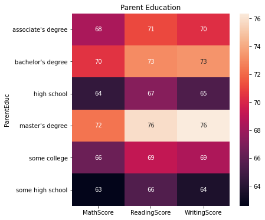

```python
plt.figure(figsize=(6,6))
sns.heatmap(gb,annot=True)
plt.title('Parent Education')
plt.show()
```

### Based on the chart above, we have concluded that parents' education has a positive impact on their children's scores.

```python
gb1=df.groupby('ParentMaritalStatus').agg({'MathScore':'mean','ReadingScore':'mean','WritingScore':'mean'})
gb
```

| ParentEduc | MathScore | ReadingScore | WritingScore |
| --- | --- | --- | --- |
| associate's degree | 68.365586 | 71.124324 | 70.299099 |
| bachelor's degree | 70.466627 | 73.062020 | 73.331069 |
| high school | 64.435731 | 67.213997 | 65.421136 |
| master's degree | 72.336134 | 75.832921 | 76.356896 |
| some college | 66.390472 | 69.179708 | 68.501432 |
| some high school | 62.584013 | 65.510785 | 63.632409 |

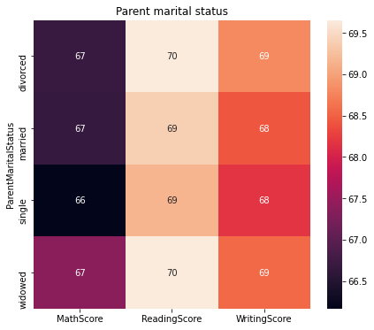

```python
plt.figure(figsize=(7,6))
sns.heatmap(gb1,annot=True)
plt.title('Parent marital status')
plt.show()
```

### Based on the chart above, we have concluded that there is no significant impact on students' scores due to their parents' marital status.

```python
gb2=df.groupby('IsFirstChild').agg({'MathScore':'mean','ReadingScore':'mean','WritingScore':'mean'})
gb2
```

| IsFirstChild | MathScore | ReadingScore | WritingScore |
| --- | --- | --- | --- |
| no | 66.246832 | 69.132614 | 68.210887 |
| yes | 66.740646 | 69.542553 | 68.558484 |

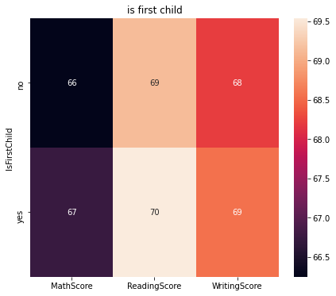

```python
plt.figure(figsize=(7,6))
sns.heatmap(gb2,annot=True)
plt.title('is first child')
plt.show()
```

### The graph above clearly indicates that a child's position as the firstborn has no discernible effect on their school performance.

```python
gb3=df.groupby('TransportMeans').agg({'MathScore':'mean','ReadingScore':'mean','WritingScore':'mean'})
gb3
```

| TransportMeans | MathScore | ReadingScore | WritingScore |
| --- | --- | --- | --- |
| private | 66.511354 | 69.472364 | 68.509593 |
| school_bus | 66.674636 | 69.446206 | 68.492351 |

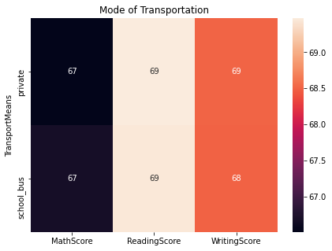

```python
plt.figure(figsize=(7,5))
sns.heatmap(gb3,annot=True)
plt.title('Mode of Transportation')
plt.show()
```

### The mode of transportation, whether it is a private vehicle or a school bus, does not influence the performance of students.

```python
gb4=df.groupby('WklyStudyHours').agg({'MathScore':'mean','ReadingScore':'mean','WritingScore':'mean'})
gb4
```

| WklyStudyHours | MathScore | ReadingScore | WritingScore |
| --- | --- | --- | --- |
| 5 - 10 | 66.870491 | 69.660532 | 68.636280 |
| < 5 | 64.580359 | 68.176135 | 67.090192 |
| > 10 | 68.696655 | 70.365436 | 69.777778 |

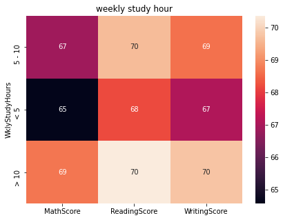

```python
plt.figure(figsize=(7,5))
sns.heatmap(gb4,annot=True)
plt.title('weekly study hour')
plt.show()
```

### Students who study more than 10 hours weekly tend to have higher scores in Math, Reading, and Writing compared to those who study less.

```python
gb5=df.groupby('NrSiblings').agg({'MathScore':'mean','ReadingScore':'mean','WritingScore':'mean'})
gb5
```

| NrSiblings | MathScore | ReadingScore | WritingScore |
| --- | --- | --- | --- |
| 0.0 | 66.819449 | 69.547812 | 68.746515 |
| 1.0 | 66.473896 | 69.259097 | 68.245345 |
| 2.0 | 66.554934 | 69.472018 | 68.522533 |
| 3.0 | 66.719092 | 69.488159 | 68.650498 |
| 4.0 | 66.245495 | 69.144169 | 68.073444 |
| 5.0 | 66.630303 | 69.453788 | 68.282576 |
| 6.0 | 65.917219 | 68.801325 | 67.860927 |
| 7.0 | 67.615120 | 69.828179 | 68.986254 |

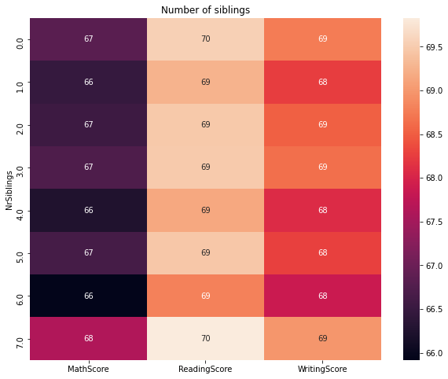

```python
plt.figure(figsize=(10,8))
sns.heatmap(gb5,annot=True)
plt.title('Number of siblings')
plt.show()
```

### From the graph above, it is evident that the number of siblings has no impact on the child's study performance.

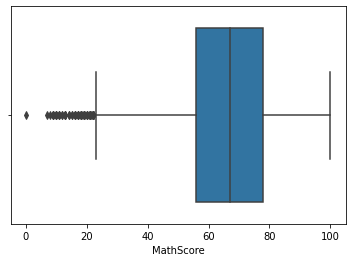

```python
sns.boxplot(data=df,x='MathScore')
plt.show()
```

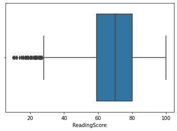

```python
sns.boxplot(data=df,x='ReadingScore')
plt.show()
```

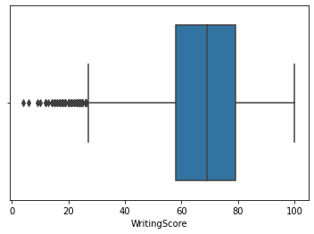

```python
sns.boxplot(data=df,x='WritingScore')
plt.show()
```

```python
print(df['EthnicGroup'].unique())
```

```
[nan 'group C' 'group B' 'group A' 'group D' 'group E']
```

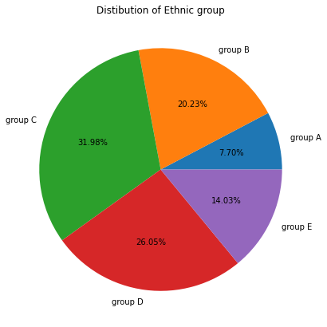

```python
groupA=df.loc[(df['EthnicGroup']=='group A')].count()
groupB=df.loc[(df['EthnicGroup']=='group B')].count()
groupC=df.loc[(df['EthnicGroup']=='group C')].count()
groupD=df.loc[(df['EthnicGroup']=='group D')].count()
groupE=df.loc[(df['EthnicGroup']=='group E')].count()
l=['group A','group B','group C','group D','group E']
plt.figure(figsize=(7,7))
mlist=[groupA['EthnicGroup'],groupB['EthnicGroup'],groupC['EthnicGroup'],groupD['EthnicGroup'],groupE['EthnicGroup']]
plt.pie(mlist,labels=l,autopct='%1.2f%%')
plt.title('Distibution of Ethnic group')
```

[output not shown]

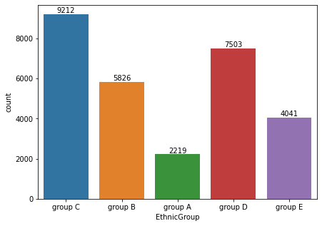

```python
plt.figure(figsize=(7,5))
ax=sns.countplot(data=df,x='EthnicGroup')
ax.bar_label(ax.containers[0])
```